# CAJEROS MADRID

[figure not shown]

[figure not shown]

[figure not shown]

[figure not shown]

[figure not shown]

[figure not shown]

# PRESENTACIÓN

El presente trabajo trata de buscar relaciones entre los cajeros automáticos de Madrid Capital y algunas características sociodemográficas del entorno como son Población y Renta Neta Media.  
Todos los ficheros se obtienen de páginas Web del Ayuntamiento de Madrid.

Pero antes 3 consideraciones:

### Fichero de cajeros automáticos

Es el fichero del que parto. Portal de Datos abiertos del Ayuntamiento de Madrid. Relación de los cajeros automáticos situados “en línea de fachada con acceso desde la vía publica” y por lo cual están obligados a pagar una Tasa. Esto implica que no recoge los que se encuentran en una ubicacíón interior dentro del establecimiento

### Consideración del entorno

Entendemos “entorno” como la “sección censal” de la ubicación del cajero automático. Podemos decir que es la unidad mínima de la que disponemos de información estadística. La división administrativa de Madrid Capital está formada por “Distrito - Barrio - Sección Censal”"

### Referencias temporales

En cada fichero se detalla la fecha de los datos

# CAJEROS

–Fichero con los Cajeros de Madrid Capital situados en la vía pública (1.348) y por lo cual están obligados a pagar una tasa.

–Fichero de actualización anual. Fecha de incorporación al “catálogo de datos abiertos” el 07-08-2018.

Contiene datos del año 2018 (primer campo del fichero) sin especificar una fecha concreta

–Portal de datos abiertos del Ayuntamiento de Madrid [https://datos.madrid.es/portal/site/egob]  
–Cajeros en vía pública [https://datos.madrid.es/egob/catalogo/300206-1-cajeros-via-publica.xlsx]

-Ordeno el fichero resultante por “dirección”, entendida como la unión de “Tipo de la vía + Nombre de la vía + Número de la vía”

```
# A tibble: 6 x 3
  TipoVia NomVia          Numero
  <chr>   <chr>           <chr>
1 AVENIDA ABRANTES        000042
2 AVENIDA ABRANTES        000054
3 AVENIDA ABRANTES        000080
4 AVENIDA ALBERTO ALCOCER 000001
5 AVENIDA ALBERTO ALCOCER 000013
6 AVENIDA ALBERTO ALCOCER 000018
```

# CALLEJERO

–Fichero que contiene todas las direcciones de Madrid. Presenta el listado de viales vigentes (unos 10.000) y portales y/o edificios de la ciudad (unos 200.000), con gran  
detalle de los mismos.

–Selecciono los siguientes campos  
-Dirección –>para poder cruzar  
-Distrito-Barrio-Sección Censal –>ya que en algunos registros del fichero de Cajeros vienen sin rellenar  
-Coordenadas geográficas en formato “S.R. ETRS89/WGS8-4”" para poder geolocalizarlas en el mapa de Madrid

–Fichero de actualización mensual. Fecha de incorporación al “catálogo de datos abiertos” el 12-03-2014

–Portal de datos abiertos del Ayuntamiento de Madrid [https://datos.madrid.es/portal/site/egob]  
–Callejero. Información adicional asociada [https://datos.madrid.es/egob/catalogo/200075-1-callejero.csv]

Elimino duplicados para quedarme con una Sección Censal para cada “dirección”. Esto es debido a duplicados en una misma dirección (portal a, portal b, portal 2…)

```
# A tibble: 6 x 8
  TipoVia NomVia        Numero CodDis CodBar SecCen Longitud    Latitud
  <chr>   <chr>         <chr>  <chr>  <chr>  <chr>  <chr>       <chr>
1 ACCESO  COLONIA MARC~ 000001 17     1      106    3:42'2.31'~ 40:20'8.2~
2 ACCESO  COLONIA MARC~ 000003 17     1      106    3:42'2.16'~ 40:20'6.1~
3 ACCESO  COLONIA MARC~ 000004 17     1      106    3:42'2.91'~ 40:20'5.1~
4 ACCESO  COLONIA MARC~ 000009 17     1      106    3:42'1.85'~ 40:19'56.~
5 ACCESO  COLONIA MARC~ 000011 17     1      106    3:42'1.85'~ 40:19'56.~
6 ACCESO  PARÑUE DE LA~ 000001 14     4      083    3:39'25.2'~ 40:25'0.9~
```

# RENTA

Fichero con la “renta neta media” de los hogares por Tramos y Sección Censal. Indicador facilitado por el INE al Ayuntamiento de Madrid, fruto de la colaboración de este con la Agencia Estatal de Administración Tributaria

–Portal web del Ayuntamiento de Madrid [https://www.madrid.es/portal/site/munimadrid]

–Renta neta media de los hogares (Urban Audit) [https://www.madrid.es/UnidadesDescentralizadas/UDCEstadistica/Nuevaweb/Econom%C3%ADa/Renta/Urban%20Audit/D3300218.xls]

–El último fichero disponible es del año 2015

–me agrupa la “renta neta media” de los hogares por Tramos (10 en total)

```
# A tibble: 6 x 5
  CodDis SecCen CodBar Tramo Renta
  <chr>  <chr>  <chr>  <dbl> <chr>
1 01     001    1          9 Entre 47.635 y 59.985
2 01     002    1          4 Entre 26.415 y 29.042
3 01     003    1          5 Entre 29.042 y 32.182
4 01     004    1          8 Entre 47.635 y 59.985
5 01     006    1          7 Entre 40.980 y 47.635
6 01     007    1          6 Entre 32.182 y 36.119
```

# POBLACIÓN

–Fichero que contiene los datos del Padrón del Ayuntamiento de Madrid. El fichero está desglosado por género y nacionalidad (española o no), por lo que acumulo para obtener la población de cada Sección Censal

–Fichero de actualización mensual. Fecha de incorporación al “catálogo de datos abiertos” el 12-03-2014

–Portal de datos abiertos del Ayuntamiento de Madrid [https://datos.madrid.es/portal/site/egob]  
–Padrón Municipal [https://datos.madrid.es/egob/catalogo/200076-1-padron.csv]

```
  CodDis CodBar SecCen Poblacion
1      1      1      1      1138
2      1      1      2       889
3      1      1      3      1723
4      1      1      4      1249
5      1      1      6      1677
6      1      1      7       819
```

# CAJEROS-CALLEJERO

–A la dirección del Cajero le añado Distrito, Barrio, Sección Censal y las Coordenadas Geográficas

–Hay unos pocos registros del fichero inicial de Cajeros (y que detallo al final) que no cruzan por uno de estos 2 motivos:

1 - El “número”" de la vía viene a “0”, por lo que no pueden cruzar  
2 - Otros con todos los datos rellenos y que no aparecen en el fichero del callejero. En alguno de los 2 ficheros la dirección no es correcta

```
# A tibble: 1,335 x 8
   TipoVia NomVia       Numero CodDis CodBar SecCen Longitud   Latitud
   <chr>   <chr>        <chr>  <chr>  <chr>  <chr>  <chr>      <chr>
 1 AVENIDA ABRANTES     000042 11     7      171    3:43'37.8~ 40:22'54.3~
 2 AVENIDA ABRANTES     000054 11     7      169    3:43'42.6~ 40:22'50.3~
 3 AVENIDA ABRANTES     000080 11     7      165    3:43'50.3~ 40:22'44.8~
 4 AVENIDA ALBERTO ALC~ 000001 05     5      070    3:41'19.5~ 40:27'33.7~
 5 AVENIDA ALBERTO ALC~ 000013 05     5      073    3:41'9.26~ 40:27'32.4~
 6 AVENIDA ALBERTO ALC~ 000026 05     4      067    3:41'3.3'~ 40:27'30.6~
 7 AVENIDA ALBERTO ALC~ 000029 05     5      074    3:41'0.21~ 40:27'31.7~
 8 AVENIDA ALBERTO ALC~ 000046 05     4      061    3:40'48.6~ 40:27'30.0~
 9 AVENIDA ALBERTO ALC~ 000048 05     4      061    3:40'44.3~ 40:27'30.3~
10 AVENIDA ALBUFERA     000014 13     2      042    3:40'4.99~ 40:23'51.1~
# ... with 1,325 more rows
```

```
# A tibble: 13 x 3
   TipoVia   NomVia                     Numero
   <chr>     <chr>                      <chr>
 1 AVENIDA   ALBERTO ALCOCER            000018
 2 AVENIDA   COMPLUTENSE                000017
 3 AVENIDA   MONASTERIO DE SILOS        000065
 4 AVENIDA   PUERTA DE HIERRO           000000
 5 CALLE     BRAVO MURILLO              000361
 6 CALLE     EINSTEIN                   000000
 7 CALLE     GINZO DE LIMIA             000000
 8 CALLE     JULIAN GONZALEZ SEGADOR    000000
 9 CALLE     NUESTRA SEÑORA DE VALVERDE 000035
10 CALLE     SAN CIPRIANO               000029
11 CARRETERA VILLAVERDE A VALLECAS      000380
12 CARRETERA VILLAVERDE A VALLECAS      003500
13 PLAZA     PABLO RUIZ PICASSO         000000
```

# CAJEROS-CALLEJERO-RENTA

–Al fichero anterior le añado la “renta neta media” de los Hogares a nivel Sección Censal

–Hay unos pocos registros del fichero de Cajeros-Callejero (y que detallo al final) que no cruzan por que la combinación de “Distrito-Barrio-Sección Censal” no aparece en el fichero de Renta Neta Media

–Posteriormente creo una función para pasar las coordenadas de tipo S.R. ETRS89/WGS84 a decimales y la aplico a las coordenadas del fichero de arrastre añadiendo las columnas de Longitud y Latitud

```
# A tibble: 1,316 x 10
   TipoVia NomVia Numero CodDis CodBar SecCen Longitud Latitud Tramo Renta
   <chr>   <chr>  <chr>  <chr>  <chr>  <chr>  <chr>    <chr>   <dbl> <chr>
 1 CALLE   LEGAN~ 000047 01     1      001    3:42'39~ 40:25'~     9 Entr~
 2 CALLE   GRAN ~ 000047 01     1      003    3:42'27~ 40:25'~     5 Entr~
 3 CALLE   GRAN ~ 000067 01     1      003    3:42'36~ 40:25'~     5 Entr~
 4 CALLE   CUCHI~ 000014 01     1      008    3:42'29~ 40:24'~     6 Entr~
 5 PLAZA   SAN M~ 000002 01     1      008    3:42'33~ 40:24'~     6 Entr~
 6 PLAZA   SAN M~ 000009 01     1      008    3:42'34~ 40:24'~     6 Entr~
 7 CALLE   CAVA ~ 000001 01     1      009    3:42'29~ 40:24'~     6 Entr~
 8 CALLE   TOLEDO 000046 01     1      012    3:42'28~ 40:24'~     4 Entr~
 9 CALLE   TOLEDO 000052 01     1      012    3:42'29~ 40:24'~     4 Entr~
10 CALLE   TOLEDO 000054 01     1      012    3:42'30~ 40:24'~     4 Entr~
# ... with 1,306 more rows
```

```
# A tibble: 19 x 8
   TipoVia NomVia         Numero CodDis CodBar SecCen Longitud   Latitud
   <chr>   <chr>          <chr>  <chr>  <chr>  <chr>  <chr>      <chr>
 1 CALLE   EMBAJADORES    000177 02     5      112    3:41'35.9~ 40:23'32~
 2 CALLE   EMBAJADORES    000177 02     5      112    3:41'35.9~ 40:23'32~
 3 AVENIDA CIUDAD DE BAR~ 000204 03     2      100    3:40'22.3~ 40:24'0.~
 4 PASEO   SAN MILLAN DE~ 000016 08     6      185    3:40'6.19~ 40:30'13~
 5 AVENIDA MONTECARMELO   000011 08     7      183    3:41'54.9~ 40:30'11~
 6 CALLE   MORALES        000010 11     6      197    3:45'22.7~ 40:21'41~
 7 CALLE   FUENTE CARRAN~ 000039 14     3      094    3:37'52.8~ 40:24'29~
 8 AVENIDA OROVILLA       000060 17     4      116    3:41'23.2~ 40:21'27~
 9 AVENIDA ENSANCHE DE V~ 000076 18     3      049    3:36'5.77~ 40:21'50~
10 CALLE   ALAMEDA DEL V~ 000034 18     3      060    3:37'13.6~ 40:21'56~
11 AVENIDA ENSANCHE DE V~ 000067 18     3      064    3:35'58.9~ 40:21'51~
12 CALLE   CALAHORRA      000002 19     1      022    3:36'36.1~ 40:24'28~
13 AVENIDA DAROCA         000317 19     1      025    3:36'47.8~ 40:24'24~
14 BULEVAR INDALECIO PRI~ 000032 19     2      036    3:37'20.9~ 40:23'54~
15 CALLE   ALPUJARRAS     000002 19     2      037    3:37'20.7~ 40:23'47~
16 AVENIDA GRAN VIA DEL ~ 000004 19     3      040    3:35'44.9~ 40:24'11~
17 AVENIDA GRAN VIA DEL ~ 000010 19     3      040    3:35'46.6~ 40:24'9.~
18 CALLE   MINERVA        000103 19     3      042    3:36'23.5~ 40:23'44~
19 CALLE   JULIAN CAMARI~ 000057 20     1      125    3:37'10.3~ 40:26'16~
```

# CAJEROS-CALLEJERO-RENTA-POBLACIÓN

Al fichero de arrastre le añado la población de las Secciones Censales

```
# A tibble: 1,316 x 13
   TipoVia NomVia Numero CodDis CodBar SecCen Longitud Latitud Tramo Renta
   <chr>   <chr>  <chr>   <dbl>  <dbl>  <dbl> <chr>    <chr>   <dbl> <chr>
 1 CALLE   LEGAN~ 000047      1      1      1 3:42'39~ 40:25'~     9 Entr~
 2 CALLE   GRAN ~ 000047      1      1      3 3:42'27~ 40:25'~     5 Entr~
 3 CALLE   GRAN ~ 000067      1      1      3 3:42'36~ 40:25'~     5 Entr~
 4 CALLE   CUCHI~ 000014      1      1      8 3:42'29~ 40:24'~     6 Entr~
 5 PLAZA   SAN M~ 000002      1      1      8 3:42'33~ 40:24'~     6 Entr~
 6 PLAZA   SAN M~ 000009      1      1      8 3:42'34~ 40:24'~     6 Entr~
 7 CALLE   CAVA ~ 000001      1      1      9 3:42'29~ 40:24'~     6 Entr~
 8 CALLE   TOLEDO 000046      1      1     12 3:42'28~ 40:24'~     4 Entr~
 9 CALLE   TOLEDO 000052      1      1     12 3:42'29~ 40:24'~     4 Entr~
10 CALLE   TOLEDO 000054      1      1     12 3:42'30~ 40:24'~     4 Entr~
# ... with 1,306 more rows, and 3 more variables: LatitudD <dbl>,
#   LongitudD <dbl>, Poblacion <dbl>
```

```
# A tibble: 0 x 13
# ... with 13 variables: TipoVia <chr>, NomVia <chr>, Numero <chr>,
#   CodDis <dbl>, CodBar <dbl>, SecCen <dbl>, Longitud <chr>,
#   Latitud <chr>, Tramo <dbl>, Renta <chr>, LatitudD <dbl>,
#   LongitudD <dbl>, Poblacion <dbl>
```

# GEOLOCALIZACIÓN

–Cargo el paquete “caRtociudad”" para geolocalizar los Cajeros  
y “ggmap”" para situarlos en el Mapa

–Después marco los límites de las coordenadas con los valores  
Max y Min de Latitud y Longitud

–Fijo el Centro con el punto medio de las Coordenadas y un  
límite de 20 kms desde este punto

–Parece bastante evidente que los Cajeros se acumulan en la denominada  
“almendra central”

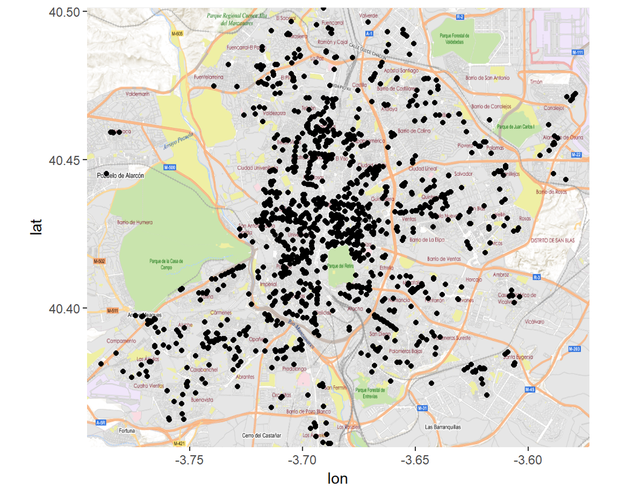

# ACUMULACIÓN

–Acumulo Cajeros por Distrito-Barrio-Sección Censal con el fin de obtener el fichero definitivo de trabajo: Total de Cajeros por Sección Censal

Selecciono solo los Campos que me interesan

```
# A tibble: 817 x 14
   TipoVia NomVia Numero CodDis CodBar SecCen Longitud Latitud Tramo Renta
   <chr>   <chr>  <chr>   <dbl>  <dbl>  <dbl> <chr>    <chr>   <dbl> <chr>
 1 CALLE   LEGAN~ 000047      1      1      1 3:42'39~ 40:25'~     9 Entr~
 2 CALLE   GRAN ~ 000047      1      1      3 3:42'27~ 40:25'~     5 Entr~
 3 CALLE   CUCHI~ 000014      1      1      8 3:42'29~ 40:24'~     6 Entr~
 4 CALLE   CAVA ~ 000001      1      1      9 3:42'29~ 40:24'~     6 Entr~
 5 CALLE   TOLEDO 000046      1      1     12 3:42'28~ 40:24'~     4 Entr~
 6 CARRERA SAN F~ 000005      1      1     14 3:42'43~ 40:24'~     5 Entr~
 7 CALLE   TOLEDO 000077      1      2     24 3:42'32~ 40:24'~     2 Entr~
 8 CALLE   DUÑUE~ 000004      1      2     25 3:42'20~ 40:24'~     6 Entr~
 9 CALLE   TOLEDO 000033      1      2     26 3:42'26~ 40:24'~     5 Entr~
10 CALLE   DUÑUE~ 000007      1      2     28 3:42'21~ 40:24'~     3 Entr~
# ... with 807 more rows, and 4 more variables: LatitudD <dbl>,
#   LongitudD <dbl>, Poblacion <dbl>, freq <int>
```

# CAJEROS POR SECCIÓN CENSAL

–Representación gráfica de la variable cuantitativa discreta “Cajeros”,  
que representa el total de Cajeros por Sección Censal

–Vemos que la mayoría de las Secciones cuenta con 1 o a lo sumo 2 Cajeros

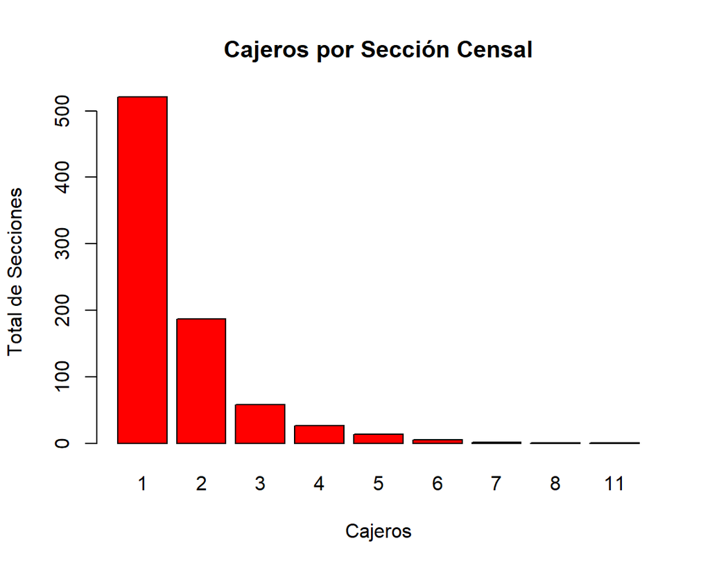

# RENTA POR SECCIÓN CENSAL

–Representación gráfica de la variable categórica ordinal “Renta”,  
que representa la “Renta Neta Media” de los Hogares por Sección Censal

–Parece que la tendencia es que haya más Cajeros a mayor nivel de Renta

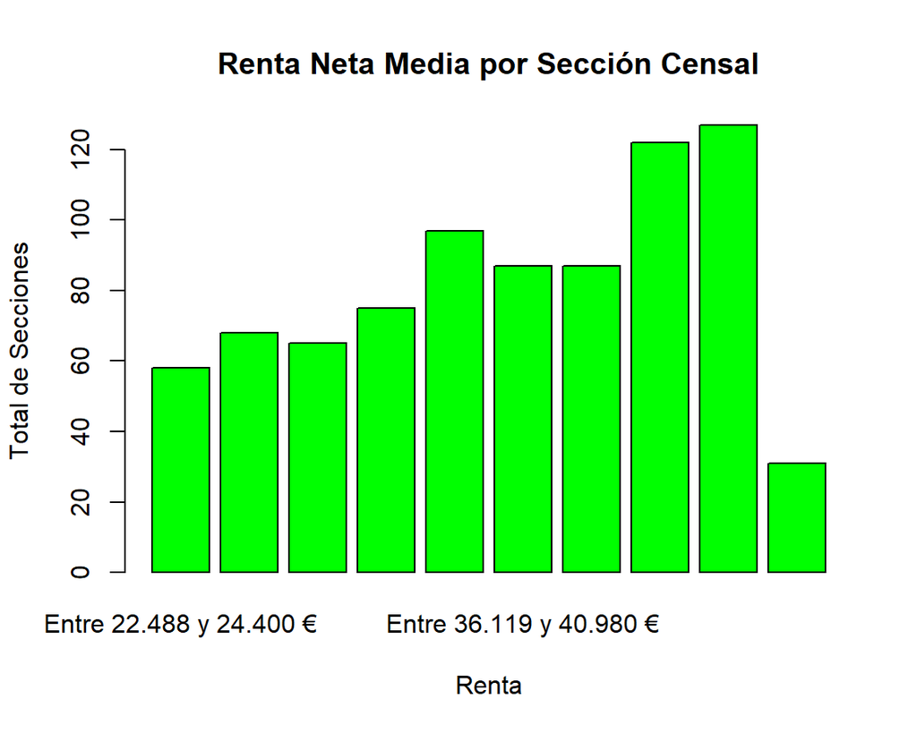

# POBLACIÓN POR SECCIÓN CENSAL

–Representación gráfica de la variable cuantitativa continua “Población”,  
que representa la Población por Sección Censal

–La mayor parte de la Población vive en Secciones Censales de entre 1.000 y 2.000 habitantes

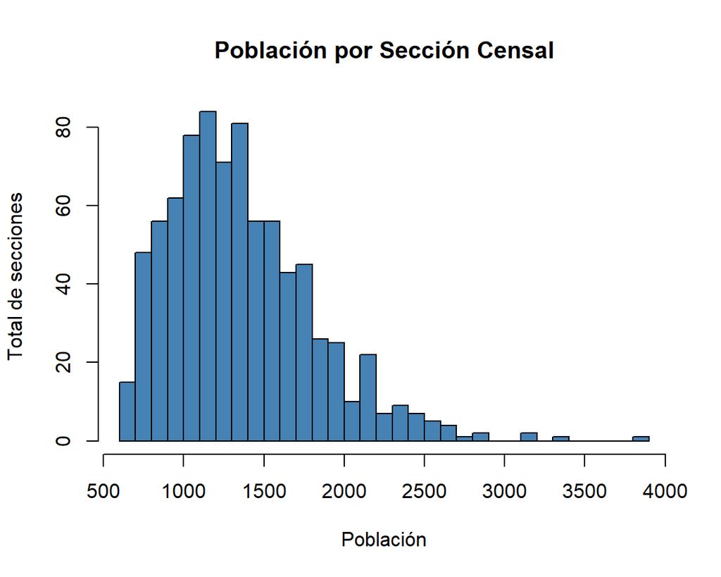

# POBLACIÓN-CAJEROS

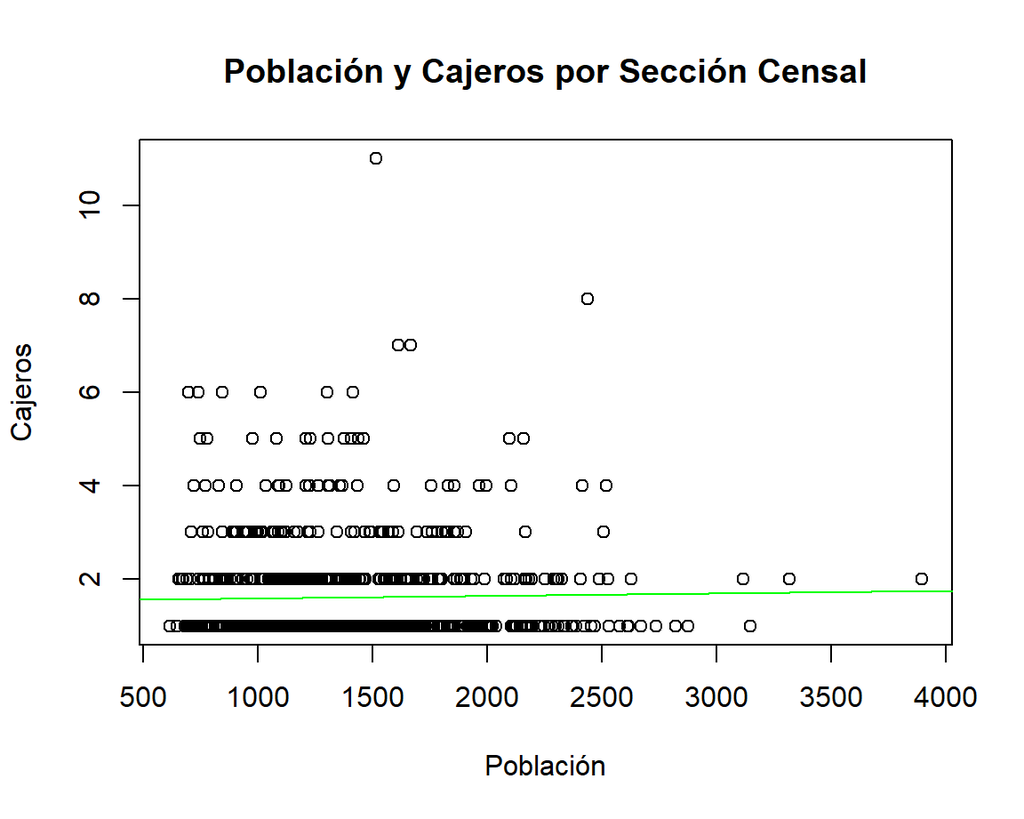

```
Call:
lm(formula = cajeros_Madrid_defi$Cajeros ~ cajeros_Madrid_defi$Poblacion)

Residuals:
    Min      1Q  Median      3Q     Max
-0.7063 -0.6129 -0.5906  0.3928  9.3809

Coefficients:
                               Estimate Std. Error t value Pr(>|t|)
(Intercept)                   1.538e+00  1.200e-01  12.814   <2e-16 ***
cajeros_Madrid_defi$Poblacion 5.350e-05  8.377e-05   0.639    0.523
---
Signif. codes:  0 '***' 0.001 '**' 0.01 '*' 0.05 '.' 0.1 ' ' 1

Residual standard error: 1.081 on 815 degrees of freedom
Multiple R-squared:  0.0005002, Adjusted R-squared:  -0.0007262
F-statistic: 0.4078 on 1 and 815 DF,  p-value: 0.5232
```

### Resumen de la regresión

Gráfico de dispersión de las 2 variables numéricas “Cajeros” y “Población”.

Con un p-valor superior al 0.5 y una medida de la bondad del ajuste (R2) rondando el “0” podemos decir que el modelo dice muy poco acerca de la variable de interés

# RENTA-CAJEROS

–Diagrama de caja de la relación entre las variables “número de cajeros” y  
el nivel de “renta neta media”

–No se ven diferencias apreciables entre los diversos niveles de renta

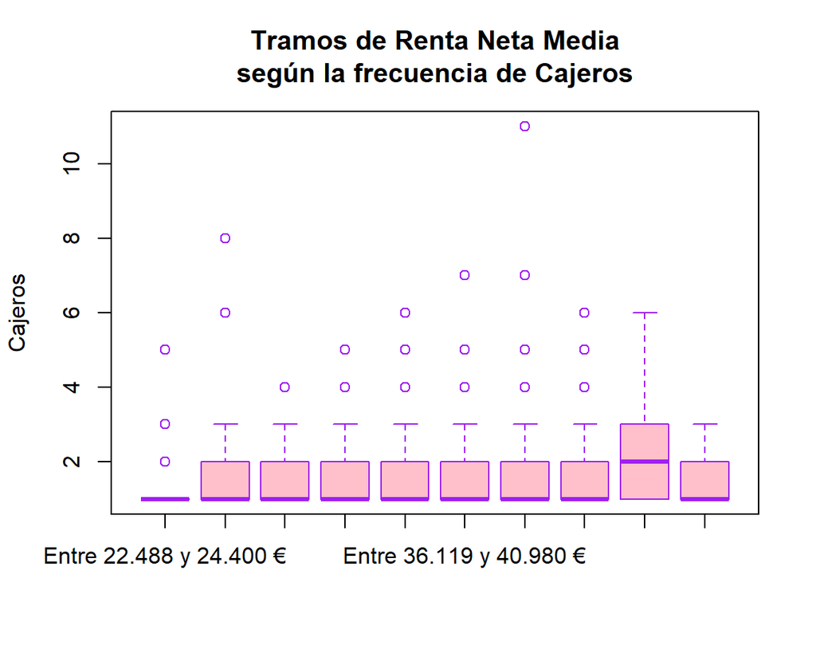

# CONCLUSIÓN

No encuentro una relación significativa entre la presencia de Cajeros y las características sociodemográficas (Población y Renta Neta Media) de la sección censal a la que pertenece

# SESSIOINFO

```
R version 3.5.1 (2018-07-02)
Platform: x86_64-w64-mingw32/x64 (64-bit)
Running under: Windows 10 x64 (build 17134)

Matrix products: default

locale:
[1] LC_COLLATE=Spanish_Spain.1252  LC_CTYPE=Spanish_Spain.1252
[3] LC_MONETARY=Spanish_Spain.1252 LC_NUMERIC=C
[5] LC_TIME=Spanish_Spain.1252

attached base packages:
[1] stats     graphics  grDevices utils     datasets  methods   base

other attached packages:
 [1] ggmap_2.6.1           caRtociudad_0.6.2     plyr_1.8.4
 [4] forcats_0.3.0         stringr_1.3.1         dplyr_0.7.6
 [7] purrr_0.2.5           readr_1.1.1           tidyr_0.8.1
[10] tibble_1.4.2          ggplot2_3.0.0         tidyverse_1.2.1
[13] readxl_1.1.0          flexdashboard_0.5.1.1

loaded via a namespace (and not attached):
 [1] tidyselect_0.2.4  reshape2_1.4.3    haven_1.1.2
 [4] lattice_0.20-35   colorspace_1.3-2  htmltools_0.3.6
 [7] yaml_2.2.0        utf8_1.1.4        rlang_0.2.2
[10] pillar_1.3.0      glue_1.3.0        withr_2.1.2
[13] sp_1.3-1          modelr_0.1.2      bindrcpp_0.2.2
[16] jpeg_0.1-8        bindr_0.1.1       munsell_0.5.0
[19] gtable_0.2.0      cellranger_1.1.0  rvest_0.3.2
[22] mapproj_1.2.6     RgoogleMaps_1.4.2 evaluate_0.11
[25] labeling_0.3      knitr_1.20        curl_3.2
[28] fansi_0.3.0       proto_1.0.0       broom_0.5.0
[31] Rcpp_0.12.18      geosphere_1.5-7   scales_1.0.0
[34] backports_1.1.2   jsonlite_1.5      rjson_0.2.20
[37] png_0.1-7         hms_0.4.2         digest_0.6.16
[40] stringi_1.1.7     grid_3.5.1        rprojroot_1.3-2
[43] cli_1.0.0         tools_3.5.1       maps_3.3.0
[46] magrittr_1.5      lazyeval_0.2.1    crayon_1.3.4
[49] pkgconfig_2.0.2   xml2_1.2.0        lubridate_1.7.4
[52] assertthat_0.2.0  rmarkdown_1.10    httr_1.3.1
[55] rstudioapi_0.7    R6_2.2.2          nlme_3.1-137
[58] compiler_3.5.1
```